# Principios y Prácticas de SEM y MLM (5ed)

Tema 3.2 Full SEM

Author

Affiliation

Efraín García Sánchez

CIMCYC — Universidad de Granada

Published

May 15, 2026

# Práctica: Full SEM

## Práctica: Full SEM

## Preparar el ambiente de trabajo

Este bloque carga los paquetes necesarios para la práctica.

```r
library(tidyverse)
library(easystats)
library(lavaanExtra)  # para formatode salida de lavaan
library(tidySEM)      # para formatode salida de lavaan
library(lavaan)       # Para modelos SEM
library(semTools)     # Para fiabilidad y otros relacionadas con SEM
library(semPlot)      # Para visualizar modelos SEM
```

## Importar los datos: solo numéricos (recomendado para evitar conflictos con paquetes)

Este bloque importa la base de datos que se usará en la práctica.

```r
data <- readr::read_csv(
  here::here("data",
  "northampton_student_health_data_package",
  "northampton_student_health_numeric.csv"))

glimpse(data)
```

```
Rows: 590
Columns: 61
$ id                             <dbl> 1, 2, 3, 4, 5, 6, 7, 8, 9, 10, 11, 12, …
$ age_group                      <dbl> 1, 1, 1, 1, 1, 1, 2, 4, 1, 1, 1, 1, 1, …
$ gender                         <dbl> 2, 1, 1, 1, 1, 2, 1, 1, 2, 2, 2, 2, 2, …
$ sexual_orientation             <dbl> 1, 2, 1, 3, 1, 1, 1, 1, 1, 1, 1, 1, 1, …
$ ethnicity                      <dbl> 1, 1, 1, 2, 1, 3, 1, 1, 1, 3, 1, 1, 1, …
$ study_mode                     <dbl> 1, 1, 1, 1, 1, 1, 1, 2, 1, 1, 1, 1, 1, …
$ study_level                    <dbl> 3, 3, 3, 3, 2, 6, 4, 3, 1, 2, 1, 1, 1, …
$ living_situation               <dbl> 1, 2, 1, 3, 2, 4, 3, 3, 1, 2, 4, 1, 1, …
$ phys_health                    <dbl> 3, 4, 4, 3, 4, 5, 5, 1, 4, 4, 4, 5, 5, …
$ ment_health                    <dbl> 4, 3, 2, 4, 3, 3, 2, 1, 4, 4, 3, 5, 3, …
$ social_connect                 <dbl> 4, 3, 1, 1, 2, 3, 2, 4, 4, 3, 3, 3, 2, …
$ sitting_weekday_hours          <dbl> 8, 5, 7, 9, NA, 5, 11, 13, 6, 5, 12, 6,…
$ sleep_quality                  <dbl> 8, 7, 4, 7, 2, 5, 3, 8, 7, 2, 9, 7, 3, …
```

[output cut: 48 more lines]

## Preparar los datos

Este bloque prepara variables auxiliares para el modelo.

```r
data <- data |>
  mutate(# creo variable dummy para género (Female vs Male)
         gender_female = case_when(gender == 1 ~ 1, # Female
                                   gender == 2 ~ 0, # Male
                                   .default = NULL),
         # creo una variable de etnia para los grupos más grandes
         ethnicity_cat = case_when(ethnicity == 1 ~ "White",
                                 ethnicity == 3 ~ "Black",
                                 ethnicity == 4 ~ "Asian",
                                 TRUE ~ NA_character_),
         # ordeno la variable de etnia en niveles (White es la referencia)
         ethnicity_cat = factor(ethnicity_cat,
                                levels = c("White", "Black", "Asian")),
         # Creo una variable dummy para ver diferencias con White
         ethnicity_black = ifelse(test = ethnicity_cat == "Black",
                                  yes = 1, no = 0),
         ethnicity_asian = ifelse(test = ethnicity_cat == "Asian",
                                  yes = 1, no = 0),
         # creo una variable categórica con pa_activity
         pa_activity_level_cat = case_when(pa_activity_level == 0 ~ "0_Inactive",
                                       pa_activity_level == 1 ~ "1_Fairly_Active",
                                       pa_activity_level == 2 ~ "2_Active")
         )
```

## Especificar el modelo

Este bloque escribe el modelo en sintaxis de lavaan.

```r
m1 <- '
  # Modelo de medición
  wellbeing =~ ment_health + phys_health + social_connect + sleep_quality
  substances =~ caffeine_non_exam + alcohol_freq + nicotine_freq
  eat_unhealthy =~ eat_processed_meat + eat_convenience_food + eat_fast_food

  # Modelo estructural
  wellbeing ~ substances + eat_unhealthy
'
```

## Estimar el modelo

Este bloque estima el modelo especificado.

```r
m1_fit <- lavaan::sem(
  model = m1,
  estimator = "ML",
  data = data)
```

## Evaluar el modelo

Este bloque revisa el ajuste y la salida general del modelo.

```r
summary(m1_fit,
        standardized = TRUE,
        ci = TRUE,
        fit.measures = TRUE)
```

```
lavaan 0.6-21 ended normally after 51 iterations

  Estimator                                         ML
  Optimization method                           NLMINB
  Number of model parameters                        23

  Number of observations                           590

Model Test User Model:

  Test statistic                                87.753
  Degrees of freedom                                32
  P-value (Chi-square)                           0.000

Model Test Baseline Model:

  Test statistic                               920.954
  Degrees of freedom                                45
  P-value                                        0.000

User Model versus Baseline Model:

  Comparative Fit Index (CFI)                    0.936
  Tucker-Lewis Index (TLI)                       0.910

Loglikelihood and Information Criteria:

  Loglikelihood user model (H0)             -10327.752
  Loglikelihood unrestricted model (H1)     -10283.875

  Akaike (AIC)                               20701.504
  Bayesian (BIC)                             20802.247
  Sample-size adjusted Bayesian (SABIC)      20729.229

Root Mean Square Error of Approximation:

  RMSEA                                          0.054
  90 Percent confidence interval - lower         0.041
  90 Percent confidence interval - upper         0.068
  P-value H_0: RMSEA <= 0.050                    0.281
```

[output cut: 74 more lines]

```
    eat_unhealthy     0.603    0.119    5.056    0.000    0.369    0.837
   Std.lv  Std.all
    0.238    0.214
    0.495    0.650
    0.749    0.749
    3.161    0.779
    5.337    0.866
    2.563    0.887
    4.024    0.602
    2.037    0.772
    0.943    0.483
    0.774    0.524
    0.835    0.835
    1.000    1.000
    1.000    1.000
```

## Evaluar el modelo

Este bloque revisa el ajuste y la salida general del modelo.

```r
lavaan::fitmeasures(m1_fit,
                    output = "text")
```

```
Model Test User Model:

  Test statistic                                87.753
  Degrees of freedom                                32
  P-value                                        0.000

Model Test Baseline Model:

  Test statistic                               920.954
  Degrees of freedom                                45
  P-value                                        0.000

User Model versus Baseline Model:

  Comparative Fit Index (CFI)                    0.936
  Tucker-Lewis Index (TLI)                       0.910
  Bentler-Bonett Non-normed Fit Index (NNFI)     0.910
  Bentler-Bonett Normed Fit Index (NFI)          0.905
  Parsimony Normed Fit Index (PNFI)              0.643
  Bollen's Relative Fit Index (RFI)              0.866
  Bollen's Incremental Fit Index (IFI)           0.937
  Relative Noncentrality Index (RNI)             0.936

Loglikelihood and Information Criteria:

  Loglikelihood user model (H0)             -10327.752
  Loglikelihood unrestricted model (H1)     -10283.875

  Akaike (AIC)                               20701.504
  Bayesian (BIC)                             20802.247
  Sample-size adjusted Bayesian (SABIC)      20729.229

Root Mean Square Error of Approximation:

  RMSEA                                          0.054
  90 Percent confidence interval - lower         0.041
  90 Percent confidence interval - upper         0.068
  P-value H_0: RMSEA <= 0.050                    0.281
  P-value H_0: RMSEA >= 0.080                    0.001

Standardized Root Mean Square Residual:

  RMR                                            0.107
  RMR (No Mean)                                  0.107
  SRMR                                           0.046

Other Fit Indices:

  Hoelter Critical N (CN) alpha = 0.05         311.582
  Hoelter Critical N (CN) alpha = 0.01         360.606

  Goodness of Fit Index (GFI)                    0.973
  Adjusted Goodness of Fit Index (AGFI)          0.953
  Parsimony Goodness of Fit Index (PGFI)         0.566

  McDonald Fit Index (MFI)                       0.954

  Expected Cross-Validation Index (ECVI)         0.227
```

## Reportar el modelo

Este bloque organiza los parámetros del modelo para su interpretación.

```r
parameters::parameters(m1_fit,
            ci = 0.95,
            standardize = TRUE)
```

|  | To | Operator | From | Coefficient | SE | CI_low | CI_high | z | p | Component |
| --- | --- | --- | --- | --- | --- | --- | --- | --- | --- | --- |
| 1 | wellbeing | =~ | ment_health | 0.88630797 | 0.03136670 | 0.8248304 | 0.94778558 | 28.256333 | 0.000000e+00 | Loading |
| 2 | wellbeing | =~ | phys_health | 0.59176144 | 0.03444783 | 0.5242449 | 0.65927795 | 17.178482 | 0.000000e+00 | Loading |
| 3 | wellbeing | =~ | social_connect | 0.50096972 | 0.03684531 | 0.4287542 | 0.57318521 | 13.596567 | 0.000000e+00 | Loading |
| 4 | wellbeing | =~ | sleep_quality | 0.47022284 | 0.03771253 | 0.3963076 | 0.54413805 | 12.468609 | 0.000000e+00 | Loading |
| 5 | substances | =~ | caffeine_non_exam | 0.36555398 | 0.05627292 | 0.2552611 | 0.47584687 | 6.496091 | 8.243384e-11 | Loading |
| 6 | substances | =~ | alcohol_freq | 0.33662042 | 0.05590444 | 0.2270497 | 0.44619110 | 6.021354 | 1.729638e-09 | Loading |
| 7 | substances | =~ | nicotine_freq | 0.63121407 | 0.07003718 | 0.4939437 | 0.76848441 | 9.012557 | 0.000000e+00 | Loading |
| 8 | eat_unhealthy | =~ | eat_processed_meat | 0.47787469 | 0.04172634 | 0.3960926 | 0.55965681 | 11.452591 | 0.000000e+00 | Loading |
| 9 | eat_unhealthy | =~ | eat_convenience_food | 0.71923477 | 0.04292734 | 0.6350987 | 0.80337081 | 16.754701 | 0.000000e+00 | Loading |
| 10 | eat_unhealthy | =~ | eat_fast_food | 0.68996255 | 0.04247268 | 0.6067176 | 0.77320748 | 16.244854 | 0.000000e+00 | Loading |

[output cut: 3 more lines]

## Representar el modelo estructural + medición

Este bloque genera una visualización del modelo estimado.

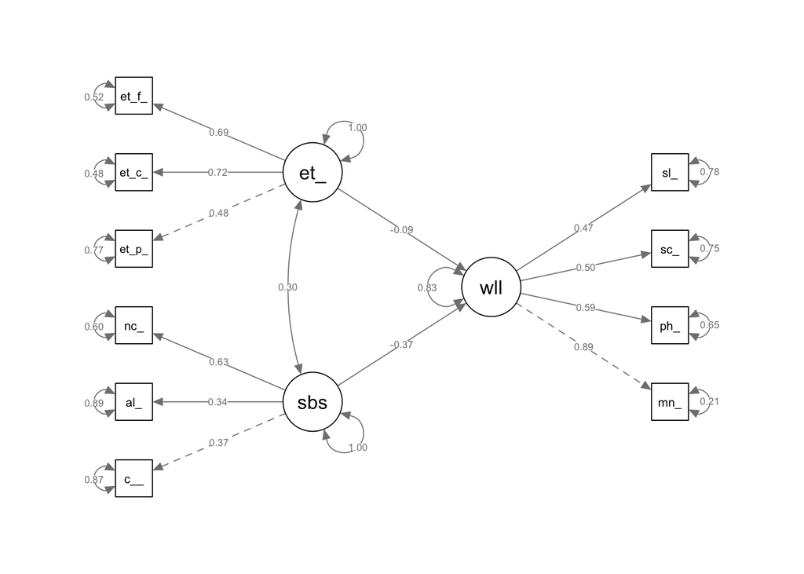

```r
semPlot::semPaths(m1_fit,
                  whatLabels = "std",
                  rotation = 2,
                  layout = "tree2")
```

# Ejercicio: Full SEM

## Ejercicio: Full SEM

- Replicar el ejercicio anterior con las siguientes variaciones:
  - Usar *eat_healthy* como variable predictora (*eat_fruit + eat_vegetables + eat_calcium*)
  - Adicionar covariables al modelo prediciendo “*wellbeing*”: *gender_female*, *age_group*
- Especificar el modelo
- Estimar el modelo
- Evaluar el modelo

## Solución 1. Especificar el modelo Full SEM

```r
m1_ex <- '
  # Modelo de medición
  wellbeing =~ ment_health + phys_health + social_connect + sleep_quality
  substances =~ caffeine_non_exam + alcohol_freq + nicotine_freq
  eat_healthy =~ eat_fruit + eat_vegetables + eat_calcium

  # Modelo estructural
  wellbeing ~ substances + eat_healthy + gender_female + age_group
'
```

## Solución 2. Estimar el modelo Full SEM

```r
m1_ex_fit <- lavaan::sem(
  model = m1_ex,
  estimator = "ML",
  data = data
)
```

## Solución 3. Evaluar el modelo Full SEM

```r
summary(
  m1_ex_fit,
  standardized = TRUE,
  ci = TRUE,
  fit.measures = TRUE,
  rsquare = TRUE
)
```

```
lavaan 0.6-21 ended normally after 49 iterations

  Estimator                                         ML
  Optimization method                           NLMINB
  Number of model parameters                        25

                                                  Used       Total
  Number of observations                           544         590

Model Test User Model:

  Test statistic                               110.839
  Degrees of freedom                                50
  P-value (Chi-square)                           0.000

Model Test Baseline Model:

  Test statistic                              1021.319
  Degrees of freedom                                65
  P-value                                        0.000

User Model versus Baseline Model:

  Comparative Fit Index (CFI)                    0.936
  Tucker-Lewis Index (TLI)                       0.917

Loglikelihood and Information Criteria:

  Loglikelihood user model (H0)              -9750.778
  Loglikelihood unrestricted model (H1)      -9695.359

  Akaike (AIC)                               19551.556
  Bayesian (BIC)                             19659.030
  Sample-size adjusted Bayesian (SABIC)      19579.671

Root Mean Square Error of Approximation:

  RMSEA                                          0.047
  90 Percent confidence interval - lower         0.035
  90 Percent confidence interval - upper         0.059
```

[output cut: 93 more lines]

```
    1.000    1.000

R-Square:
                   Estimate
    ment_health       0.831
    phys_health       0.308
    social_connect    0.252
    sleep_quality     0.203
    caffeine_nn_xm    0.205
    alcohol_freq      0.132
    nicotine_freq     0.297
    eat_fruit         0.489
    eat_vegetables    0.585
    eat_calcium       0.364
    wellbeing         0.290
```

## Solución 4. Índices de ajuste del modelo Full SEM

```r
lavaan::fitmeasures(
  m1_ex_fit,
  output = "text"
)
```

```
Model Test User Model:

  Test statistic                               110.839
  Degrees of freedom                                50
  P-value                                        0.000

Model Test Baseline Model:

  Test statistic                              1021.319
  Degrees of freedom                                65
  P-value                                        0.000

User Model versus Baseline Model:

  Comparative Fit Index (CFI)                    0.936
  Tucker-Lewis Index (TLI)                       0.917
  Bentler-Bonett Non-normed Fit Index (NNFI)     0.917
  Bentler-Bonett Normed Fit Index (NFI)          0.891
  Parsimony Normed Fit Index (PNFI)              0.686
  Bollen's Relative Fit Index (RFI)              0.859
  Bollen's Incremental Fit Index (IFI)           0.937
  Relative Noncentrality Index (RNI)             0.936

Loglikelihood and Information Criteria:

  Loglikelihood user model (H0)              -9750.778
  Loglikelihood unrestricted model (H1)      -9695.359

  Akaike (AIC)                               19551.556
  Bayesian (BIC)                             19659.030
  Sample-size adjusted Bayesian (SABIC)      19579.671

Root Mean Square Error of Approximation:

  RMSEA                                          0.047
  90 Percent confidence interval - lower         0.035
  90 Percent confidence interval - upper         0.059
  P-value H_0: RMSEA <= 0.050                    0.629
  P-value H_0: RMSEA >= 0.080                    0.000

Standardized Root Mean Square Residual:

  RMR                                            0.139
  RMR (No Mean)                                  0.139
  SRMR                                           0.045

Other Fit Indices:

  Hoelter Critical N (CN) alpha = 0.05         332.315
  Hoelter Critical N (CN) alpha = 0.01         374.765

  Goodness of Fit Index (GFI)                    0.962
  Adjusted Goodness of Fit Index (AGFI)          0.941
  Parsimony Goodness of Fit Index (PGFI)         0.617

  McDonald Fit Index (MFI)                       0.946

  Expected Cross-Validation Index (ECVI)         0.296
```

## Solución 5. Reportar parámetros del modelo Full SEM

```r
parameters::parameters(
  m1_ex_fit,
  ci = 0.95,
  standardize = TRUE
) |>
  display()
```

# Loading

| Link | Coefficient | SE | 95% CI | z | p |
| --- | --- | --- | --- | --- | --- |
| wellbeing =~ ment_health | 0.91 | 0.03 | (0.85, 0.97) | 29.71 | < .001 |
| wellbeing =~ phys_health | 0.55 | 0.04 | (0.48, 0.63) | 15.46 | < .001 |
| wellbeing =~ social_connect | 0.50 | 0.04 | (0.43, 0.58) | 13.39 | < .001 |
| wellbeing =~ sleep_quality | 0.45 | 0.04 | (0.37, 0.53) | 11.54 | < .001 |
| substances =~ caffeine_non_exam | 0.45 | 0.06 | (0.34, 0.57) | 7.78 | < .001 |
| substances =~ alcohol_freq | 0.36 | 0.06 | (0.25, 0.48) | 6.32 | < .001 |
| substances =~ nicotine_freq | 0.54 | 0.06 | (0.42, 0.67) | 8.87 | < .001 |
| eat_healthy =~ eat_fruit | 0.70 | 0.04 | (0.63, 0.77) | 19.71 | < .001 |
| eat_healthy =~ eat_vegetables | 0.76 | 0.04 | (0.70, 0.83) | 21.75 | < .001 |
| eat_healthy =~ eat_calcium | 0.60 | 0.04 | (0.53, 0.68) | 16.41 | < .001 |

# Regression

| Link | Coefficient | SE | 95% CI | z | p |
| --- | --- | --- | --- | --- | --- |
| wellbeing ~ substances | -0.42 | 0.07 | (-0.56, -0.29) | -6.04 | < .001 |
| wellbeing ~ eat_healthy | 0.23 | 0.06 | (0.11, 0.34) | 3.80 | < .001 |
| wellbeing ~ gender_female | -0.20 | 0.04 | (-0.29, -0.12) | -4.92 | < .001 |
| wellbeing ~ age_group | 0.27 | 0.04 | (0.19, 0.35) | 6.74 | < .001 |

# Correlation

| Link | Coefficient | SE | 95% CI | z | p |
| --- | --- | --- | --- | --- | --- |
| substances eat_healthy | 0.31 | 0.07 | (0.17, 0.45) | 4.40 | < .001 |
| gender_female age_group | -0.02 | 0.00 | (-0.02, -0.02) |  | < .001 |

## Solución 6. Visualizar el modelo Full SEM

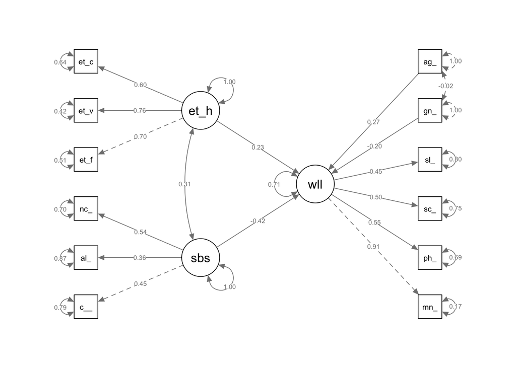

```r
semPlot::semPaths(
  m1_ex_fit,
  whatLabels = "std",
  rotation = 2,
  layout = "tree2"
)
```

## Solución 7. Interpretación del modelo Full SEM

- El modelo evalúa si **substances** y **eat_healthy** predicen el factor latente **wellbeing**.
- A diferencia de la práctica, el factor alimenticio representa un patrón saludable, medido por fruta, verdura y calcio.
- Las covariables **gender_female** y **age_group** se interpretan como predictores adicionales de **wellbeing**.
- La interpretación debe considerar simultáneamente el ajuste global, las cargas factoriales y los caminos estructurales hacia **wellbeing**.

# Práctica: Mediación con modelos SEM

## Especificar el modelo

Este bloque escribe el modelo en sintaxis de lavaan.

```r
m2 <- '
  # Modelo de medición
  wellbeing =~ ment_health + phys_health + social_connect + sleep_quality
  substances =~ caffeine_non_exam + alcohol_freq + nicotine_freq
  eat_unhealthy =~ eat_processed_meat + eat_convenience_food + eat_fast_food

  # Modelo estructural
  substances ~ a*eat_unhealthy
  wellbeing ~ b*substances + c*eat_unhealthy

  # Efecto indirecto
  indirecto:= a*b
  directo := c
  total := a*b + c

  # Tamaño del efecto indirecto (de forma descriptiva, pero inestables)
  proporcion := indirecto/total # cuánto del efecto *total* es por el indirecto
  ratio := indirecto/directo    # cuánto es el efecto indirecto en relación al
'
```

## Estimar el modelo

Este bloque estima el modelo especificado.

```r
m2_fit <- lavaan::sem(
  model = m2,
   bootstrap = 100L, # aumentar a 1000 o 5000 para resultados más estables
   test = "bootstrap",
  data = data)
```

## Evaluar el modelo

Este bloque revisa el ajuste y la salida general del modelo.

```r
summary(m2_fit,
        std = TRUE,
        ci = TRUE,
        fit.measures = TRUE)
```

```
lavaan 0.6-21 ended normally after 51 iterations

  Estimator                                         ML
  Optimization method                           NLMINB
  Number of model parameters                        23

  Number of observations                           590

Model Test User Model:

  Test statistic                                87.753
  Degrees of freedom                                32
  P-value (Chi-square)                           0.000

  Test statistic                                87.753
  Degrees of freedom                                32
  P-value (Bollen-Stine bootstrap)               0.000

Model Test Baseline Model:

  Test statistic                               920.954
  Degrees of freedom                                45
  P-value                                        0.000

User Model versus Baseline Model:

  Comparative Fit Index (CFI)                    0.936
  Tucker-Lewis Index (TLI)                       0.910

Loglikelihood and Information Criteria:

  Loglikelihood user model (H0)             -10327.752
  Loglikelihood unrestricted model (H1)     -10283.875

  Akaike (AIC)                               20701.504
  Bayesian (BIC)                             20802.247
  Sample-size adjusted Bayesian (SABIC)      20729.229

Root Mean Square Error of Approximation:

```

[output cut: 88 more lines]

```
    1.000    1.000

Defined Parameters:
                   Estimate  Std.Err  z-value  P(>|z|) ci.lower ci.upper
    indirecto        -0.134    0.045   -2.966    0.003   -0.222   -0.045
    directo          -0.108    0.074   -1.465    0.143   -0.253    0.037
    total            -0.242    0.068   -3.541    0.000   -0.376   -0.108
    proporcion        0.553    0.217    2.543    0.011    0.127    0.979
    ratio             1.237    1.088    1.137    0.256   -0.896    3.370
   Std.lv  Std.all
   -0.111   -0.111
   -0.090   -0.090
   -0.202   -0.202
    0.553    0.553
    1.237    1.237
```

## Evaluar el modelo

Este bloque revisa el ajuste y la salida general del modelo.

```r
lavaan::fitmeasures(m2_fit,
                    output = "text")
```

```
Model Test User Model:

  Test statistic                                87.753
  Degrees of freedom                                32
  P-value                                        0.000

Model Test Baseline Model:

  Test statistic                               920.954
  Degrees of freedom                                45
  P-value                                        0.000

User Model versus Baseline Model:

  Comparative Fit Index (CFI)                    0.936
  Tucker-Lewis Index (TLI)                       0.910
  Bentler-Bonett Non-normed Fit Index (NNFI)     0.910
  Bentler-Bonett Normed Fit Index (NFI)          0.905
  Parsimony Normed Fit Index (PNFI)              0.643
  Bollen's Relative Fit Index (RFI)              0.866
  Bollen's Incremental Fit Index (IFI)           0.937
  Relative Noncentrality Index (RNI)             0.936

Loglikelihood and Information Criteria:

  Loglikelihood user model (H0)             -10327.752
  Loglikelihood unrestricted model (H1)     -10283.875

  Akaike (AIC)                               20701.504
  Bayesian (BIC)                             20802.247
  Sample-size adjusted Bayesian (SABIC)      20729.229

Root Mean Square Error of Approximation:

  RMSEA                                          0.054
  90 Percent confidence interval - lower         0.041
  90 Percent confidence interval - upper         0.068
  P-value H_0: RMSEA <= 0.050                    0.281
  P-value H_0: RMSEA >= 0.080                    0.001

Standardized Root Mean Square Residual:

  RMR                                            0.107
  RMR (No Mean)                                  0.107
  SRMR                                           0.046

Other Fit Indices:

  Hoelter Critical N (CN) alpha = 0.05         311.582
  Hoelter Critical N (CN) alpha = 0.01         360.606

  Goodness of Fit Index (GFI)                    0.973
  Adjusted Goodness of Fit Index (AGFI)          0.953
  Parsimony Goodness of Fit Index (PGFI)         0.566

  McDonald Fit Index (MFI)                       0.954

  Expected Cross-Validation Index (ECVI)         0.227
```

## Reportar el modelo

Este bloque organiza los parámetros del modelo para su interpretación.

```r
parameters::parameters(m2_fit,
            ci = 0.95,
            standardize = TRUE) |>
  display()
```

# Loading

| Link | Coefficient | SE | 95% CI | z | p |
| --- | --- | --- | --- | --- | --- |
| wellbeing =~ ment_health | 0.89 | 0.03 | (0.82, 0.95) | 28.26 | < .001 |
| wellbeing =~ phys_health | 0.59 | 0.03 | (0.52, 0.66) | 17.18 | < .001 |
| wellbeing =~ social_connect | 0.50 | 0.04 | (0.43, 0.57) | 13.60 | < .001 |
| wellbeing =~ sleep_quality | 0.47 | 0.04 | (0.40, 0.54) | 12.47 | < .001 |
| substances =~ caffeine_non_exam | 0.37 | 0.06 | (0.26, 0.48) | 6.50 | < .001 |
| substances =~ alcohol_freq | 0.34 | 0.06 | (0.23, 0.45) | 6.02 | < .001 |
| substances =~ nicotine_freq | 0.63 | 0.07 | (0.49, 0.77) | 9.01 | < .001 |
| eat_unhealthy =~ eat_processed_meat | 0.48 | 0.04 | (0.40, 0.56) | 11.45 | < .001 |
| eat_unhealthy =~ eat_convenience_food | 0.72 | 0.04 | (0.64, 0.80) | 16.75 | < .001 |
| eat_unhealthy =~ eat_fast_food | 0.69 | 0.04 | (0.61, 0.77) | 16.24 | < .001 |

# Regression

| Link | Coefficient | SE | 95% CI | z | p |
| --- | --- | --- | --- | --- | --- |
| substances ~ eat_unhealthy (a) | 0.30 | 0.07 | (0.16, 0.44) | 4.31 | < .001 |
| wellbeing ~ substances (b) | -0.37 | 0.07 | (-0.51, -0.23) | -5.29 | < .001 |
| wellbeing ~ eat_unhealthy (c) | -0.09 | 0.06 | (-0.21, 0.03) | -1.48 | 0.138 |

# Defined

| To | Coefficient | SE | 95% CI | z | p |
| --- | --- | --- | --- | --- | --- |
| (indirecto) | -0.11 | 0.04 | (-0.18, -0.04) | -3.12 | 0.002 |
| (directo) | -0.09 | 0.06 | (-0.21, 0.03) | -1.48 | 0.138 |
| (total) | -0.20 | 0.05 | (-0.31, -0.10) | -3.81 | < .001 |
| (proporcion) | 0.55 | 0.22 | (0.13, 0.98) | 2.54 | 0.011 |
| (ratio) | 1.24 | 1.09 | (-0.90, 3.37) | 1.14 | 0.256 |

## Representar el modelo estructural + medición

Este bloque genera una visualización del modelo estimado.

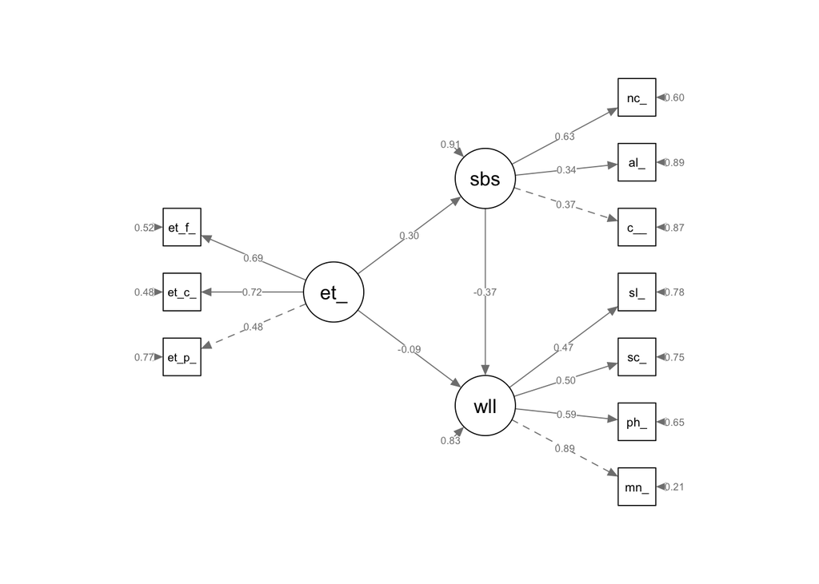

```r
semPlot::semPaths(m2_fit,
                  whatLabels = "std",
                  style = "lisrel",
                  rotation = 2,
                  layout = "tree2")
```

# Ejercicio

## Ejercicio: Mediación con SEM

- Probar la mediación usando *eat_healthy* como predictora del consumo de sustancias
  - *eat_healthy =~ eat_fruit + eat_vegetables + eat_calcium*
- Replicar el ejercicio anterior con las siguientes variaciones:
  - Usar *eat_healthy* como predictora
  - Usar *substances* como mediadora
  - Usar *wellbeing* como resultado
  - Controlar por covariables en wellbeing (*gender_female*, *age_group*)
- Estimar el efecto indirecto de **eat_healthy** sobre **wellbeing** a través de **substances**

## Solución 1. Especificar el modelo de mediación

```r
m2_ex <- '
  # Modelo de medición
  wellbeing =~ ment_health + phys_health + social_connect + sleep_quality
  substances =~ caffeine_non_exam + alcohol_freq + nicotine_freq
  eat_healthy =~ eat_fruit + eat_vegetables + eat_calcium

  # Modelo estructural
  substances ~ a*eat_healthy
  wellbeing ~ b*substances + c*eat_healthy + gender_female + age_group

  # Efectos
  indirecto := a*b
  directo := c
  total := c + (a*b)

  # Tamaños descriptivos del efecto indirecto
  proporcion := indirecto/total
  ratio := indirecto/directo
'
```

## Solución 2. Estimar el modelo de mediación

```r
m2_ex_fit <- lavaan::sem(
  model = m2_ex,
  bootstrap = 100L, # aumentar a 1000 o 5000 para resultados más estables
  test = "bootstrap",
  data = data
)
```

## Solución 3. Evaluar el modelo de mediación

```r
summary(
  m2_ex_fit,
  standardized = TRUE,
  ci = TRUE,
  fit.measures = TRUE,
  rsquare = TRUE
)
```

```
lavaan 0.6-21 ended normally after 48 iterations

  Estimator                                         ML
  Optimization method                           NLMINB
  Number of model parameters                        25

                                                  Used       Total
  Number of observations                           544         590

Model Test User Model:

  Test statistic                               110.839
  Degrees of freedom                                50
  P-value (Chi-square)                           0.000

  Test statistic                               110.839
  Degrees of freedom                                50
  P-value (Bollen-Stine bootstrap)               0.000

Model Test Baseline Model:

  Test statistic                              1021.319
  Degrees of freedom                                65
  P-value                                        0.000

User Model versus Baseline Model:

  Comparative Fit Index (CFI)                    0.936
  Tucker-Lewis Index (TLI)                       0.917

Loglikelihood and Information Criteria:

  Loglikelihood user model (H0)              -9750.778
  Loglikelihood unrestricted model (H1)      -9695.359

  Akaike (AIC)                               19551.556
  Bayesian (BIC)                             19659.030
  Sample-size adjusted Bayesian (SABIC)      19579.671

Root Mean Square Error of Approximation:
```

[output cut: 108 more lines]

```
    substances        0.098

Defined Parameters:
                   Estimate  Std.Err  z-value  P(>|z|) ci.lower ci.upper
    indirecto        -0.109    0.035   -3.126    0.002   -0.177   -0.041
    directo           0.186    0.050    3.684    0.000    0.087    0.284
    total             0.077    0.042    1.841    0.066   -0.005    0.159
    proporcion       -1.415    0.946   -1.496    0.135   -3.269    0.439
    ratio            -0.586    0.162   -3.614    0.000   -0.904   -0.268
   Std.lv  Std.all
   -0.133   -0.133
    0.227    0.227
    0.094    0.094
   -1.415   -1.415
   -0.586   -0.586
```

## Solución 4. Índices de ajuste del modelo de mediación

```r
lavaan::fitmeasures(
  m2_ex_fit,
  output = "text"
)
```

```
Model Test User Model:

  Test statistic                               110.839
  Degrees of freedom                                50
  P-value                                        0.000

Model Test Baseline Model:

  Test statistic                              1021.319
  Degrees of freedom                                65
  P-value                                        0.000

User Model versus Baseline Model:

  Comparative Fit Index (CFI)                    0.936
  Tucker-Lewis Index (TLI)                       0.917
  Bentler-Bonett Non-normed Fit Index (NNFI)     0.917
  Bentler-Bonett Normed Fit Index (NFI)          0.891
  Parsimony Normed Fit Index (PNFI)              0.686
  Bollen's Relative Fit Index (RFI)              0.859
  Bollen's Incremental Fit Index (IFI)           0.937
  Relative Noncentrality Index (RNI)             0.936

Loglikelihood and Information Criteria:

  Loglikelihood user model (H0)              -9750.778
  Loglikelihood unrestricted model (H1)      -9695.359

  Akaike (AIC)                               19551.556
  Bayesian (BIC)                             19659.030
  Sample-size adjusted Bayesian (SABIC)      19579.671

Root Mean Square Error of Approximation:

  RMSEA                                          0.047
  90 Percent confidence interval - lower         0.035
  90 Percent confidence interval - upper         0.059
  P-value H_0: RMSEA <= 0.050                    0.629
  P-value H_0: RMSEA >= 0.080                    0.000

Standardized Root Mean Square Residual:

  RMR                                            0.139
  RMR (No Mean)                                  0.139
  SRMR                                           0.045

Other Fit Indices:

  Hoelter Critical N (CN) alpha = 0.05         332.315
  Hoelter Critical N (CN) alpha = 0.01         374.765

  Goodness of Fit Index (GFI)                    0.962
  Adjusted Goodness of Fit Index (AGFI)          0.941
  Parsimony Goodness of Fit Index (PGFI)         0.617

  McDonald Fit Index (MFI)                       0.946

  Expected Cross-Validation Index (ECVI)         0.296
```

## Solución 5. Reportar efectos directos e indirectos

```r
parameters::parameters(
  m2_ex_fit,
  ci = 0.95,
  standardize = TRUE
) |>
  display()
```

# Loading

| Link | Coefficient | SE | 95% CI | z | p |
| --- | --- | --- | --- | --- | --- |
| wellbeing =~ ment_health | 0.91 | 0.03 | (0.85, 0.97) | 29.71 | < .001 |
| wellbeing =~ phys_health | 0.55 | 0.04 | (0.48, 0.63) | 15.46 | < .001 |
| wellbeing =~ social_connect | 0.50 | 0.04 | (0.43, 0.58) | 13.39 | < .001 |
| wellbeing =~ sleep_quality | 0.45 | 0.04 | (0.37, 0.53) | 11.54 | < .001 |
| substances =~ caffeine_non_exam | 0.45 | 0.06 | (0.34, 0.57) | 7.78 | < .001 |
| substances =~ alcohol_freq | 0.36 | 0.06 | (0.25, 0.48) | 6.32 | < .001 |
| substances =~ nicotine_freq | 0.54 | 0.06 | (0.42, 0.67) | 8.87 | < .001 |
| eat_healthy =~ eat_fruit | 0.70 | 0.04 | (0.63, 0.77) | 19.71 | < .001 |
| eat_healthy =~ eat_vegetables | 0.76 | 0.04 | (0.70, 0.83) | 21.75 | < .001 |
| eat_healthy =~ eat_calcium | 0.60 | 0.04 | (0.53, 0.68) | 16.41 | < .001 |

# Regression

| Link | Coefficient | SE | 95% CI | z | p |
| --- | --- | --- | --- | --- | --- |
| substances ~ eat_healthy (a) | 0.31 | 0.07 | (0.17, 0.45) | 4.40 | < .001 |
| wellbeing ~ substances (b) | -0.42 | 0.07 | (-0.56, -0.29) | -6.04 | < .001 |
| wellbeing ~ eat_healthy (c) | 0.23 | 0.06 | (0.11, 0.34) | 3.80 | < .001 |
| wellbeing ~ gender_female | -0.20 | 0.04 | (-0.29, -0.12) | -4.92 | < .001 |
| wellbeing ~ age_group | 0.27 | 0.04 | (0.19, 0.35) | 6.74 | < .001 |

# Correlation

| Link | Coefficient | SE | 95% CI | p |
| --- | --- | --- | --- | --- |
| gender_female age_group | -0.02 | 0 | (-0.02, -0.02) | < .001 |

# Defined

| To | Coefficient | SE | 95% CI | z | p |
| --- | --- | --- | --- | --- | --- |
| (indirecto) | -0.13 | 0.04 | (-0.21, -0.05) | -3.19 | 0.001 |
| (directo) | 0.23 | 0.06 | (0.11, 0.34) | 3.80 | < .001 |
| (total) | 0.09 | 0.05 | (-5.19e-03, 0.19) | 1.86 | 0.063 |
| (proporcion) | -1.42 | 0.95 | (-3.27, 0.44) | -1.50 | 0.135 |
| (ratio) | -0.59 | 0.16 | (-0.90, -0.27) | -3.61 | < .001 |

## Solución 6. Visualizar el modelo de mediación

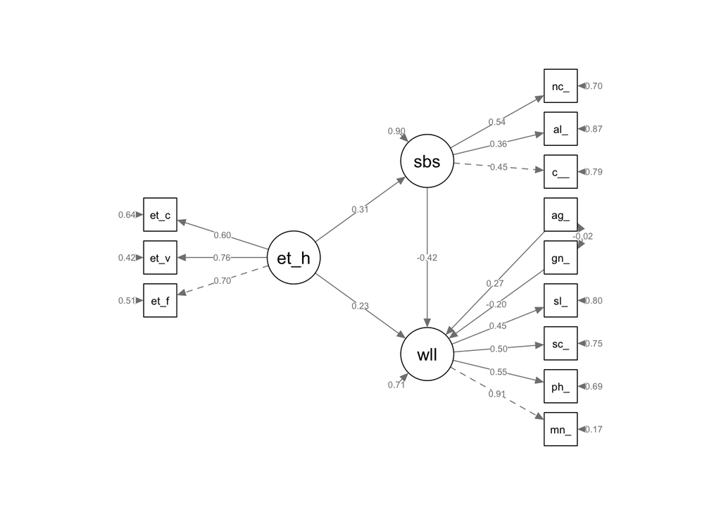

```r
semPlot::semPaths(
  m2_ex_fit,
  whatLabels = "std",
  style = "lisrel",
  rotation = 2,
  layout = "tree2"
)
```

## Solución 7. Interpretación del modelo de mediación

- El camino **a** estima si **eat_healthy** predice **substances**.
- El camino **b** estima si **substances** predice **wellbeing**, controlando por **eat_healthy** y covariables.
- El camino **c** estima el efecto directo de **eat_healthy** sobre **wellbeing**.
- El efecto **indirecto := a*b **evalúa si parte de la asociación entre** eat_healthy **y** wellbeing **ocurre a través de** substances**.
- Si el intervalo de confianza del efecto indirecto no cruza cero, hay evidencia compatible con un efecto indirecto estadísticamente distinto de cero.